# Predicting Default Risk

Classification Models 1. Logistic Regression 2. Decision Tree 3. Random Forest 4. Boosted Model

Import Data

```r
cd <- read.csv('data/credit-data-clean.csv')
prospects <- read.csv('data/prospects-data-clean.csv')
# Check datatypes
str(cd)
```

```
'data.frame':   500 obs. of  13 variables:
 $ credit.application.result        : Factor w/ 2 levels "Creditworthy",..: 1 1 1 1 1 1 2 1 1 1 ...
 $ account.balance                  : Factor w/ 2 levels "No Account","Some Balance": 2 2 2 2 1 2 1 1 1 2 ...
 $ duration.of.credit.month         : int  4 4 4 4 6 6 6 6 6 6 ...
 $ payment.status.of.previous.credit: Factor w/ 3 levels "No Problems (in this bank)",..: 2 2 1 1 2 1 3 2 2 2 ...
 $ purpose                          : Factor w/ 4 levels "Home Related",..: 3 1 1 1 1 1 1 1 1 1 ...
 $ credit.amount                    : int  1494 1494 1544 3380 343 362 433 454 484 660 ...
 $ value.savings.stocks             : Factor w/ 3 levels "< £100","£100-£1000",..: 2 2 3 3 3 1 2 3 3 2 ...
 $ length.of.current.employment     : Factor w/ 3 levels "< 1yr","1-4 yrs",..: 1 1 2 2 1 1 1 1 2 2 ...
 $ installment.per.cent             : int  1 1 2 1 4 4 4 3 3 2 ...
 $ most.valuable.available.asset    : int  1 1 1 1 1 3 2 2 1 1 ...
 $ age.years                        : num  33 29 42 37 27 52 24 22 28 23 ...
 $ type.of.apartment                : int  2 2 2 2 2 2 1 2 2 1 ...
 $ no.of.credits.at.this.bank       : Factor w/ 2 levels "1","More than 1": 1 1 2 1 1 2 1 1 1 1 ...
```

```r
# Change credit.application.result to numeric and
# installment.percent, most.valuable.available.asset, type.of.apartment to Factor
# credit.application.result
cd$credit.application.result <- as.numeric(cd$credit.application.result) - 1
# installment.per.cent
cd$installment.per.cent <- as.factor(cd$installment.per.cent)
prospects$installment.per.cent <- as.factor(prospects$installment.per.cent)
# most.valuable.available.asset
cd$most.valuable.available.asset <- as.factor(cd$most.valuable.available.asset)
prospects$most.valuable.available.asset <- as.factor(prospects$most.valuable.available.asset)
# type.of.apartment
cd$type.of.apartment <- as.factor(cd$type.of.apartment)
prospects$type.of.apartment <- as.factor(prospects$type.of.apartment)
# age.years to numeric
cd$age.years <- as.numeric(cd$age.years)
prospects$age.years <- as.numeric(prospects$age.years)
```

Correlation Between Variables

```r
# Load dependencies
library(corrr)
require(dplyr)
require(MASS)
# Check correlations of numeric variables
dplyr::select(cd, duration.of.credit.month, credit.amount, age.years) %>% correlate()
```

| rowname | duration.of.credit.month | credit.amount | age.years |
| --- | --- | --- | --- |
| duration.of.credit.month | NA | 0.57397971 | -0.06419695 |
| credit.amount | 0.57397971 | NA | 0.06931589 |
| age.years | -0.06419695 | 0.06931589 | NA |

The highest correlation is between duration.of.credit.month and credit.amount with a correlation of 0.574. As this is below 0.7, both variables were included.

Train and Test Datasets

```r
# Train (70% of observations)
cd_train <- sample_n(cd, round(0.7*nrow(cd)))
# Test (30% of observations)
cd_test <- cd[!(rownames(cd) %in% rownames(cd_train)),]
```

1. Logistic Regression

Build Stepwise Logistic Regression Model

```r
# Load Dependencies
library('BaylorEdPsych')
# Stepwise Regression
mylogit <- glm(credit.application.result ~ ., data=cd_train, family='binomial')
step <- stepAIC(mylogit, direction='both')
```

```
Start:  AIC=376.25
credit.application.result ~ account.balance + duration.of.credit.month +
    payment.status.of.previous.credit + purpose + credit.amount +
    value.savings.stocks + length.of.current.employment + installment.per.cent +
    most.valuable.available.asset + age.years + type.of.apartment +
    no.of.credits.at.this.bank

                                    Df Deviance    AIC
- most.valuable.available.asset      3   331.64 371.64
- type.of.apartment                  2   330.96 372.96
- no.of.credits.at.this.bank         1   330.27 374.27
- duration.of.credit.month           1   330.43 374.43
- purpose                            3   334.66 374.66
- installment.per.cent               3   335.66 375.66
- value.savings.stocks               2   333.86 375.86
<none>                                   330.25 376.25
- age.years                          1   332.75 376.75
- length.of.current.employment       2   335.38 377.38
- credit.amount                      1   337.70 381.70
- payment.status.of.previous.credit  2   344.26 386.26
- account.balance                    1   346.05 390.05

Step:  AIC=371.64
credit.application.result ~ account.balance + duration.of.credit.month +
    payment.status.of.previous.credit + purpose + credit.amount +
    value.savings.stocks + length.of.current.employment + installment.per.cent +
    age.years + type.of.apartment + no.of.credits.at.this.bank

                                    Df Deviance    AIC
- type.of.apartment                  2   333.30 369.30
- no.of.credits.at.this.bank         1   331.68 369.68
- duration.of.credit.month           1   331.84 369.84
- purpose                            3   336.70 370.70
- value.savings.stocks               2   335.11 371.11
- installment.per.cent               3   337.62 371.62
<none>                                   331.64 371.64
- age.years                          1   334.31 372.31
- length.of.current.employment       2   336.61 372.61
+ most.valuable.available.asset      3   330.25 376.25
- credit.amount                      1   341.73 379.73
```

[output cut: 89 more lines]

```

                                    Df Deviance    AIC
<none>                                   340.94 364.94
+ age.years                          1   339.08 365.08
- value.savings.stocks               2   345.13 365.13
+ purpose                            3   335.54 365.54
+ duration.of.credit.month           1   340.57 366.57
- length.of.current.employment       2   346.61 366.61
+ no.of.credits.at.this.bank         1   340.94 366.94
+ type.of.apartment                  2   339.82 367.82
- installment.per.cent               3   350.62 368.62
+ most.valuable.available.asset      3   338.76 368.76
- payment.status.of.previous.credit  2   356.34 376.34
- account.balance                    1   358.01 380.01
- credit.amount                      1   358.02 380.02
```

```r
PseudoR2(step)
```

```
        McFadden     Adj.McFadden        Cox.Snell       Nagelkerke McKelvey.Zavoina           Effron            Count        Adj.Count
       0.1962006        0.1349032        0.2116187        0.3012942        0.3180845        0.2471561        0.7914286        0.2912621
             AIC    Corrected.AIC
     364.9405084      365.8663245
```

ROC Curve

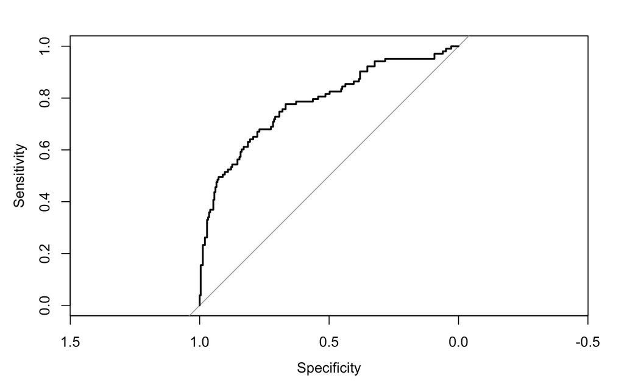

```r
# Load dependencies
library(pROC)
# Score model for training set
predict <- predict(step, cd_train, type='response')
# ROC Curve
g <- roc(credit.application.result ~ predict, data=cd_train, print.auc=TRUE)
plot(g)
```

```r
auc(g)
```

```
Area under the curve: 0.782
```

Score the Model

```r
predict <- as.data.frame(predict(step, cd_test, type='response'))
```

Confusion Matrix

```r
# Load dependencies
library(caret)
# Rename column
names(predict) <- 'Prediction'
# Add new column that names each prediction
predict$Prediction <- ifelse(predict$Prediction > 0.5, 1, 0)
# Confusion Matrix
cm.Logit <- confusionMatrix(as.factor(cd_test$credit.application.result), as.factor(predict$Prediction))
cm.Logit
```

```
Confusion Matrix and Statistics

          Reference
Prediction   0   1
         0 104   7
         1  27  12

               Accuracy : 0.7733
                 95% CI : (0.6979, 0.8376)
    No Information Rate : 0.8733
    P-Value [Acc > NIR] : 0.99977

                  Kappa : 0.2934
 Mcnemar's Test P-Value : 0.00112

            Sensitivity : 0.7939
            Specificity : 0.6316
         Pos Pred Value : 0.9369
         Neg Pred Value : 0.3077
             Prevalence : 0.8733
         Detection Rate : 0.6933
   Detection Prevalence : 0.7400
      Balanced Accuracy : 0.7127

       'Positive' Class : 0
```

2. Decision Tree

Build decision Tree

```r
# Import libraries
library(rpart)
# Grow tree
mytree <- rpart(credit.application.result ~ ., data=cd_train)
# Display the results
printcp(mytree)
```

```
Regression tree:
rpart(formula = credit.application.result ~ ., data = cd_train)

Variables actually used in tree construction:
[1] account.balance                   age.years                         credit.amount
[4] duration.of.credit.month          installment.per.cent              length.of.current.employment
[7] most.valuable.available.asset     payment.status.of.previous.credit purpose

Root node error: 72.689/350 = 0.20768

n= 350

        CP nsplit rel error  xerror     xstd
1 0.094064      0   1.00000 1.01015 0.048792
2 0.059985      1   0.90594 0.99452 0.054430
3 0.053510      2   0.84595 0.99568 0.059151
4 0.024881      3   0.79244 0.93696 0.061987
5 0.015896      4   0.76756 0.99553 0.070915
6 0.012735      8   0.69759 1.01299 0.073923
7 0.012500      9   0.68486 1.02440 0.075431
8 0.010000     11   0.65986 1.03230 0.075799
```

```r
summary.mytree <- summary(mytree)
```

```
Call:
rpart(formula = credit.application.result ~ ., data = cd_train)
  n= 350

          CP nsplit rel error    xerror       xstd
1 0.09406404      0 1.0000000 1.0101513 0.04879154
2 0.05998534      1 0.9059360 0.9945201 0.05442992
3 0.05350992      2 0.8459506 0.9956768 0.05915089
4 0.02488076      3 0.7924407 0.9369639 0.06198735
5 0.01589624      4 0.7675599 0.9955313 0.07091469
6 0.01273535      8 0.6975928 1.0129850 0.07392311
7 0.01250024      9 0.6848574 1.0244035 0.07543084
8 0.01000000     11 0.6598569 1.0323003 0.07579887

Variable importance
                  account.balance payment.status.of.previous.credit          duration.of.credit.month                     credit.amount
                               22                                17                                12                                12
             installment.per.cent     most.valuable.available.asset                         age.years      length.of.current.employment
                                9                                 8                                 5                                 4
             value.savings.stocks                           purpose        no.of.credits.at.this.bank                 type.of.apartment
                                4                                 2                                 2                                 1

Node number 1: 350 observations,    complexity param=0.09406404
  mean=0.2942857, MSE=0.2076816
  left son=2 (168 obs) right son=3 (182 obs)
  Primary splits:
      account.balance                   splits as  RL,         improve=0.09406404, (0 missing)
      payment.status.of.previous.credit splits as  LLR,        improve=0.08769480, (0 missing)
      credit.amount                     < 11788  to the left,  improve=0.04967304, (0 missing)
      duration.of.credit.month          < 31.5   to the left,  improve=0.04657204, (0 missing)
      value.savings.stocks              splits as  LLR,        improve=0.03027665, (0 missing)
  Surrogate splits:
      value.savings.stocks              splits as  RLR,        agree=0.603, adj=0.173, (0 split)
      payment.status.of.previous.credit splits as  LRR,        agree=0.589, adj=0.143, (0 split)
      no.of.credits.at.this.bank        splits as  RL,         agree=0.566, adj=0.095, (0 split)
      length.of.current.employment      splits as  RRL,        agree=0.557, adj=0.077, (0 split)
      credit.amount                     < 5947   to the left,  agree=0.554, adj=0.071, (0 split)

Node number 2: 168 observations,    complexity param=0.01250024
  mean=0.1488095, MSE=0.1266652
```

[output cut: 131 more lines]

```
  Primary splits:
      age.years                < 26.5   to the right, improve=0.117773700, (0 missing)
      credit.amount            < 7341   to the left,  improve=0.038323080, (0 missing)
      installment.per.cent     splits as  LR-L,       improve=0.010651360, (0 missing)
      duration.of.credit.month < 14.5   to the left,  improve=0.008627451, (0 missing)
      value.savings.stocks     splits as  RLR,        improve=0.008264463, (0 missing)

Node number 103: 9 observations
  mean=0.7777778, MSE=0.1728395

Node number 204: 49 observations
  mean=0.2244898, MSE=0.1740941

Node number 205: 15 observations
  mean=0.6, MSE=0.24
```

```r
dt.variable.importance <- summary.mytree$variable.importance
```

ROC Curve

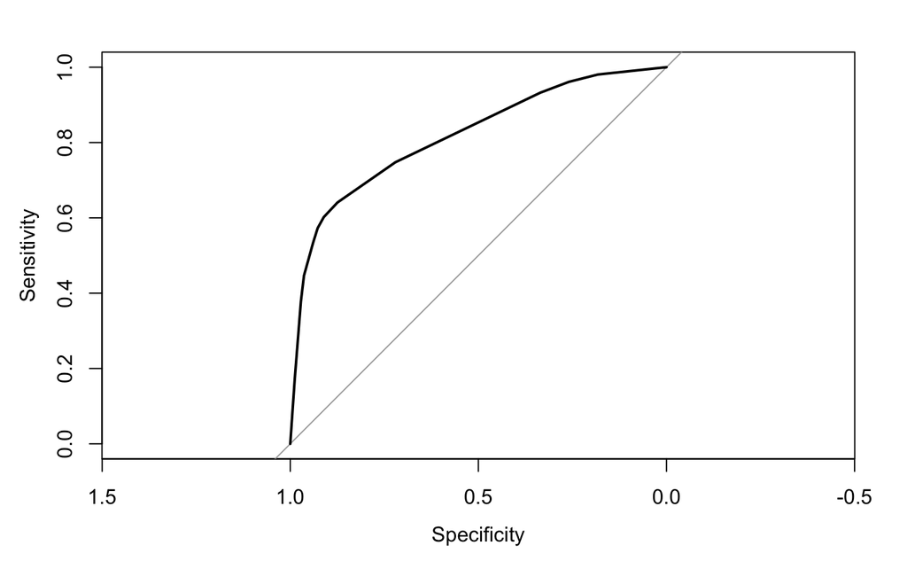

```r
# Load dependencies
library(pROC)
# Score model for training set
predict <- predict(mytree, cd_train)
# ROC Curve
g <- roc(credit.application.result ~ predict, data=cd_train)
plot(g)
```

```r
auc(g)
```

```
Area under the curve: 0.8174
```

Score Model

```r
# Load dependency
library('caret')
# Test Data
predict <- data.frame(predict(mytree, cd_test))
```

Confusion Matrix

```r
# Rename column
names(predict) <- 'Prediction'
# Add new column that names each prediction
predict$Prediction <- ifelse(predict$Prediction > 0.5, 1, 0)
# Confusion matrix - Yes/no are actual. False/True are predicted
cm.DecisionTree <- confusionMatrix(as.factor(cd_test$credit.application.result), as.factor(predict$Prediction))
cm.DecisionTree
```

```
Confusion Matrix and Statistics

          Reference
Prediction  0  1
         0 92 19
         1 24 15

               Accuracy : 0.7133
                 95% CI : (0.6339, 0.7841)
    No Information Rate : 0.7733
    P-Value [Acc > NIR] : 0.9653

                  Kappa : 0.2227
 Mcnemar's Test P-Value : 0.5419

            Sensitivity : 0.7931
            Specificity : 0.4412
         Pos Pred Value : 0.8288
         Neg Pred Value : 0.3846
             Prevalence : 0.7733
         Detection Rate : 0.6133
   Detection Prevalence : 0.7400
      Balanced Accuracy : 0.6171

       'Positive' Class : 0
```

3. Random Forest Model

Build Random Forest

```r
# Load dependencies
library('randomForest')
# do.trace displays the error rate vs. sample size
fit <- randomForest(credit.application.result ~ ., data=cd_train, importance=TRUE, ntree=100, do.trace=FALSE)
```

```
The response has five or fewer unique values.  Are you sure you want to do regression?
```

Variable Importance Plot

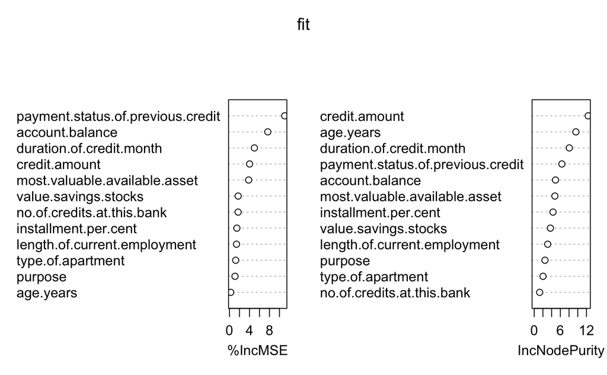

```r
varImpPlot(fit)
```

ROC Curve

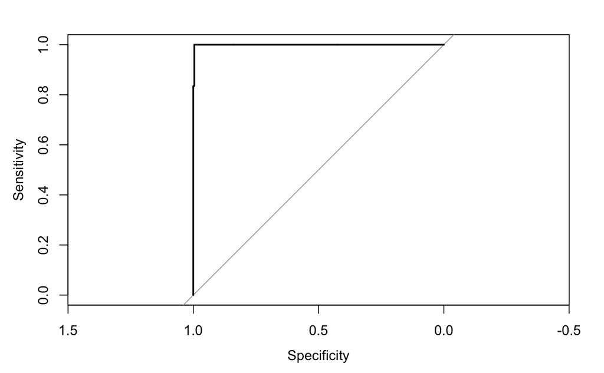

```r
# Load dependencies
library(pROC)
# Score model for training set
predict <- predict(fit, cd_train)
# ROC Curve
g <- roc(credit.application.result ~ predict, data=cd_train)
plot(g)
```

```r
auc(g)
```

```
Area under the curve: 0.9993
```

Score the Model

```r
# Predict test dataset
predict <- data.frame(predict(fit, cd_test, type='class'))
```

Confusion Matrix

```r
# Rename column
names(predict) <- 'Prediction'
# Add new column that names each prediction
predict$Prediction <- ifelse(predict$Prediction > 0.5, 1, 0)
# Confusion matrix - Yes/no are actual. False/True are predicted
cm.RandomForest <- confusionMatrix(as.factor(cd_test$credit.application.result), as.factor(predict$Prediction))
cm.RandomForest
```

```
Confusion Matrix and Statistics

          Reference
Prediction   0   1
         0 103   8
         1  18  21

               Accuracy : 0.8267
                 95% CI : (0.7564, 0.8835)
    No Information Rate : 0.8067
    P-Value [Acc > NIR] : 0.30819

                  Kappa : 0.5087
 Mcnemar's Test P-Value : 0.07756

            Sensitivity : 0.8512
            Specificity : 0.7241
         Pos Pred Value : 0.9279
         Neg Pred Value : 0.5385
             Prevalence : 0.8067
         Detection Rate : 0.6867
   Detection Prevalence : 0.7400
      Balanced Accuracy : 0.7877

       'Positive' Class : 0
```

4. Boosted Model

Build Boosted Model

```r
# Dependencies
library('gbm')
# Boosted Model
boost_model <- gbm(credit.application.result ~ ., data=cd_train, n.trees=1866)
```

```
Distribution not specified, assuming bernoulli ...
```

```
Using OOB method...
```

```
OOB generally underestimates the optimal number of iterations although predictive performance is reasonably competitive. Using cv.folds>0 when calling gbm usually results in improved predictive performance.
```

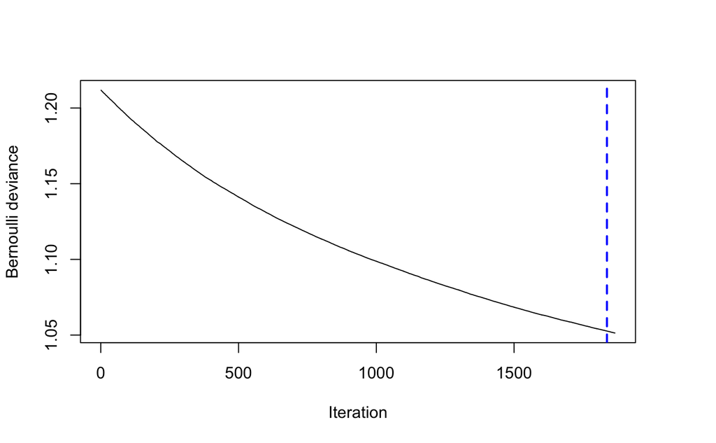

```r
# Check the best number of iterations
best.iter = gbm.perf(boost_model)
```

```r
best.iter
```

```
[1] 1837
```

Variable Importance Factors

|  | var | rel.inf |
| --- | --- | --- |
| account.balance | account.balance | 29.8799113 |
| payment.status.of.previous.credit | payment.status.of.previous.credit | 29.1122645 |
| credit.amount | credit.amount | 18.6511649 |
| duration.of.credit.month | duration.of.credit.month | 8.8308661 |
| value.savings.stocks | value.savings.stocks | 3.7843056 |
| age.years | age.years | 3.5297377 |
| most.valuable.available.asset | most.valuable.available.asset | 2.3306656 |
| purpose | purpose | 1.4359851 |
| length.of.current.employment | length.of.current.employment | 1.1772973 |
| installment.per.cent | installment.per.cent | 1.1577886 |

[output cut: 2 more lines]

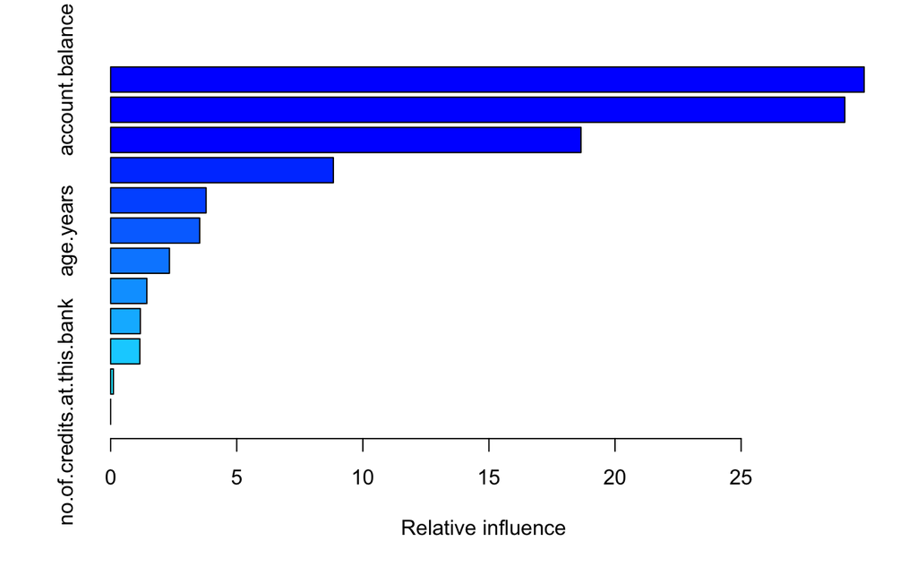

```r
# Variable Importance Factors
summary(boost_model)
```

ROC Curve

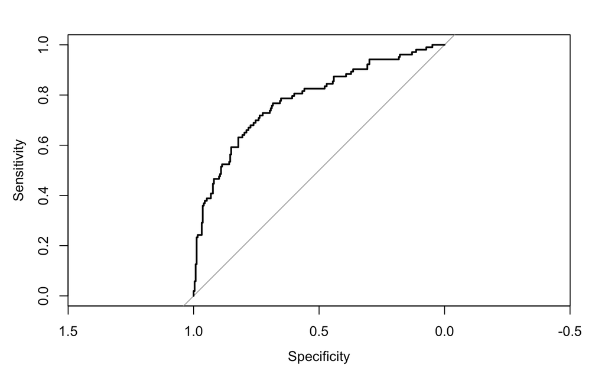

```r
# Load dependencies
library(pROC)
# Score model for training set
predict <- predict.gbm(boost_model, newdata=cd_train, n.trees=1866, type='response')
# ROC Curve
g <- roc(credit.application.result ~ predict, data=cd_train)
plot(g)
```

```r
auc(g)
```

```
Area under the curve: 0.7829
```

Score the Model

```r
# Score the model
predict <- data.frame(predict.gbm(boost_model, newdata=cd_test, n.trees=1866, type='response'))
# Rename column
names(predict) <- 'Prediction'
# Add new column that names each prediction
predict$Prediction <- ifelse(predict$Prediction > 0.5, 1, 0)
```

```r
# Confusion matrix - Yes/no are actual. False/True are predicted
cm.BoostedModel <- confusionMatrix(as.factor(cd_test$credit.application.result), as.factor(predict$Prediction))
```

Random Forest Model applied to all data

Build Random Forest

```r
# Load dependencies
library('randomForest')
# do.trace displays the error rate vs. sample size
fit <- randomForest(credit.application.result ~ ., data=cd, importance=TRUE, ntree=100, do.trace=FALSE)
```

```
The response has five or fewer unique values.  Are you sure you want to do regression?
```

Variable Importance Plot

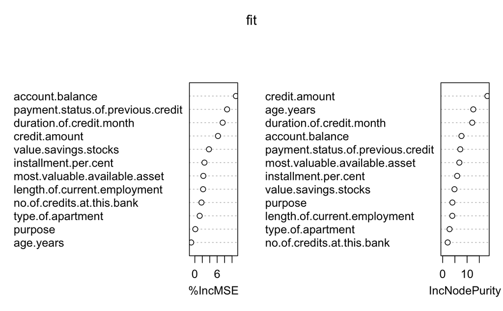

```r
varImpPlot(fit)
```

Score the Model against itself

```r
# Predict test dataset
predict <- data.frame(predict(fit, cd, type='class'))
```

Confusion Matrix

```r
# Rename column
names(predict) <- 'Prediction'
# Add new column that names each prediction
predict$Prediction <- ifelse(predict$Prediction > 0.5, 1, 0)
# Confusion matrix - Yes/no are actual. False/True are predicted
confusionMatrix(as.factor(cd$credit.application.result), as.factor(predict$Prediction))
```

```
Confusion Matrix and Statistics

          Reference
Prediction   0   1
         0 358   0
         1   8 134

               Accuracy : 0.984
                 95% CI : (0.9687, 0.9931)
    No Information Rate : 0.732
    P-Value [Acc > NIR] : < 2e-16

                  Kappa : 0.96
 Mcnemar's Test P-Value : 0.01333

            Sensitivity : 0.9781
            Specificity : 1.0000
         Pos Pred Value : 1.0000
         Neg Pred Value : 0.9437
             Prevalence : 0.7320
         Detection Rate : 0.7160
   Detection Prevalence : 0.7160
      Balanced Accuracy : 0.9891

       'Positive' Class : 0
```

Score the Prospects dataset

```r
# Make sure cd and prospects have same levels for factor variables
levels(prospects$purpose) <- levels(cd$purpose)
# Predict test dataset
predict <- data.frame(predict(fit, prospects, type='class'))
# Rename column
names(predict) <- 'Prediction'
# Add new column that names each prediction
predict$Prediction <- ifelse(predict$Prediction > 0.5, 1, 0)
count(subset(predict, Prediction == 1))
```

| n |
| --- |
| 88 |

Save File

```r
save('Predicting Default Risk.Rmd', file="PDR.RData")
```

[output not shown]